# OUP-class

#### import packages

```python
import numpy as np
import matplotlib.pyplot as plt
from tqdm import *
import statsmodels.tsa.stattools as sm
```

#### class trajectory

As an example, we use the Ornstein-Uhlenbeck process.

\begin{align*} \dot{\mathbf{v}}(t) = - \mathbf{v}(t) + \sqrt{2} \, \boldsymbol{\xi}(t). \end{align*}

```python
class Trajectory:

    def __init__(self,nP,dT):

        # initialize memory
        self.vX = np.zeros(nP)
        self.vY = np.zeros(nP)

        # save parameters
        self.dT = dT
        self.nP = nP

        # create the trajectory
        self.__MakeTrajectory()

    def __MakeTrajectory(self):

        # abbreviate the noise amplitude
        s2dt = np.sqrt(2.*self.dT)

        # initial condition
        self.vX[0] = np.random.normal(0)
        self.vY[0] = np.random.normal(0)

        # solve by iteration
        for iS in range(1,self.nP):

            self.vX[iS] = self.vX[iS-1] - self.dT*self.vX[iS-1] + s2dt*np.random.normal(0)
            self.vY[iS] = self.vY[iS-1] - self.dT*self.vY[iS-1] + s2dt*np.random.normal(0)

    def __getCorrIndex(self,x,hLag):

        # get the length of the time series
        nP = x.shape[0]

        # calculate the correlation
        corr = 0.
        for iS in range(0,nP-hLag):

            corr = corr + x[iS]*x[iS+hLag]

        # normalize properly
        corr = corr / (nP-hLag)

        return corr

    def __calcCorrelationFunction(self,x,nLags):

        # get the length of the time series
        nP = x.shape[0]

        # abbreviate the square
        inv_sq_np = 1./np.sqrt(nP)

        # reserve memory
        CorrFunc  = np.zeros(nLags + 1)
        nCorrFunc = np.zeros(nLags + 1)
        uCorrFunc = np.zeros(nLags + 1)

        # loop over the number of lags
        for iL in range(0,nLags + 1):

            CorrFunc[iL] = self.__getCorrIndex(x,iL)

        # normalize
        for iL in range(0,nLags + 1):

            nCorrFunc[iL] = CorrFunc[iL] / CorrFunc[0]

        # get the error bar
        for iL in range(1,nLags + 1):

            if 1 == iL:

                uCorrFunc[iL] = 1/np.sqrt(nP)
                continue

            if iL > 1:

                tSum = 0.

                for iS in range(1,iL):
                    tSum = tSum + np.abs(nCorrFunc[iS])
                    # tSum = tSum + (nCorrFunc[iS])**2.

                uCorrFunc[iL] = inv_sq_np * np.sqrt(1. + 2.*tSum)

                continue

        return nCorrFunc, uCorrFunc


    def getCorrFunction(self,nLags):

        # initialize memory
        self.corr_vX = np.zeros(nLags + 1)
        self.corr_vY = np.zeros(nLags + 1)

        self.u_corr_vX = np.zeros(nLags + 1)
        self.u_corr_vY = np.zeros(nLags + 1)

        # calculate the correlations for components
        self.corr_vX,self.u_corr_vX = self.__calcCorrelationFunction(self.vX,nLags)
        self.corr_vY,self.u_corr_vY = self.__calcCorrelationFunction(self.vY,nLags)

        # calculate the velocity correlations
        self.corr_V = (self.corr_vX + self.corr_vY)/2.

        # uncertainty by Gaussian propagation
        self.u_corr_V = np.sqrt( (self.u_corr_vX)**2. + (self.u_corr_vY)**2. ) / 2.
```

#### main

```python
# fix the parameters
nP = 10**4
dT = 0.05

# number of lags for the correlation function
nLags = np.floor(8./dT).astype(int)
if nLags > np.floor(nP/2.):
    nLags = np.floor(nP/2.)
    print('note: nLag too large. \n')

# number of trajectories
nT = 10**3
```

```python
# make a list of tracks
TrackList = []

# loop over the tracks
for iT in tqdm(range(0,nT)):

    # create a trajectory
    NewTrack = Trajectory(nP,dT)

    # append to list
    TrackList.append(NewTrack)
```

```python
# calculate the correlation functions of tracks
# loop over the tracks
for iT in tqdm(range(0,nT)):

    # append to list
    TrackList[iT].getCorrFunction(nLags)
```

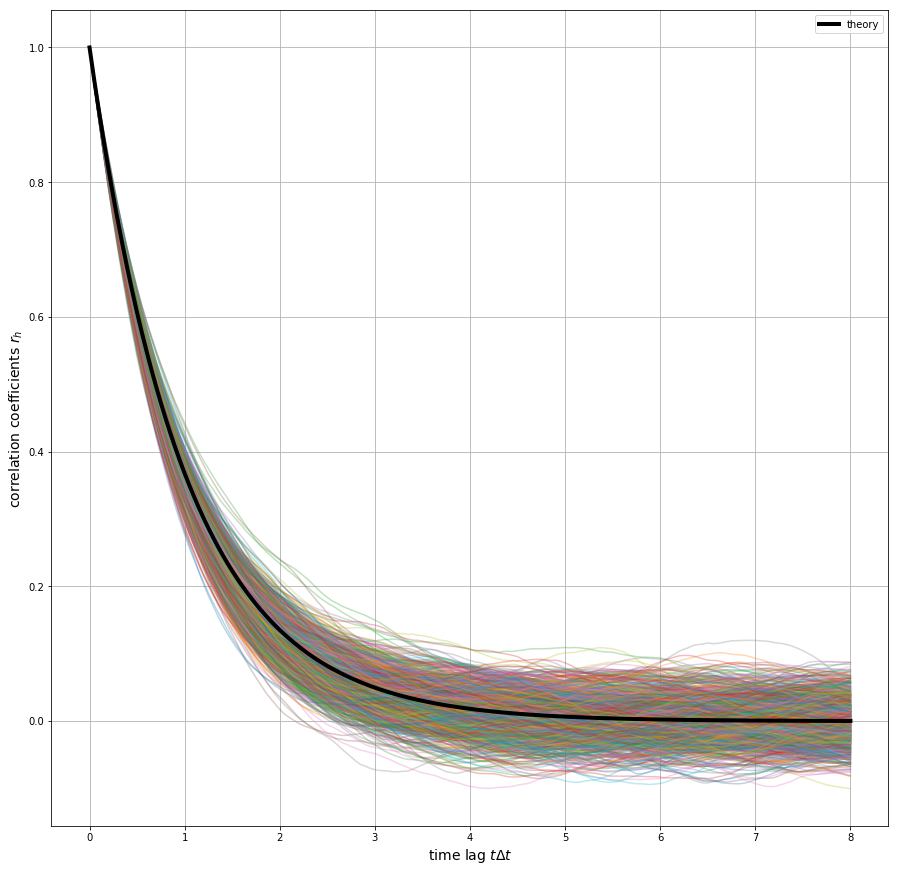

```python
# plot the correlations of individual tracks vs theory

tL = dT*np.arange(0,nLags+1)

fig,ax = plt.subplots(figsize=(15, 15))
ax.set_xlabel('time lag $t\Delta t$', fontsize=14)
ax.set_ylabel('correlation coefficients $r_h$', fontsize=14)
ax.grid()

# plot data
for iT in range(0,nT):

    ax.plot(tL,TrackList[iT].corr_V,'-',alpha=0.3)

ax.plot(tL,np.exp(-tL),label='theory',linewidth=4,color='black')

plt.legend()
plt.show()
```

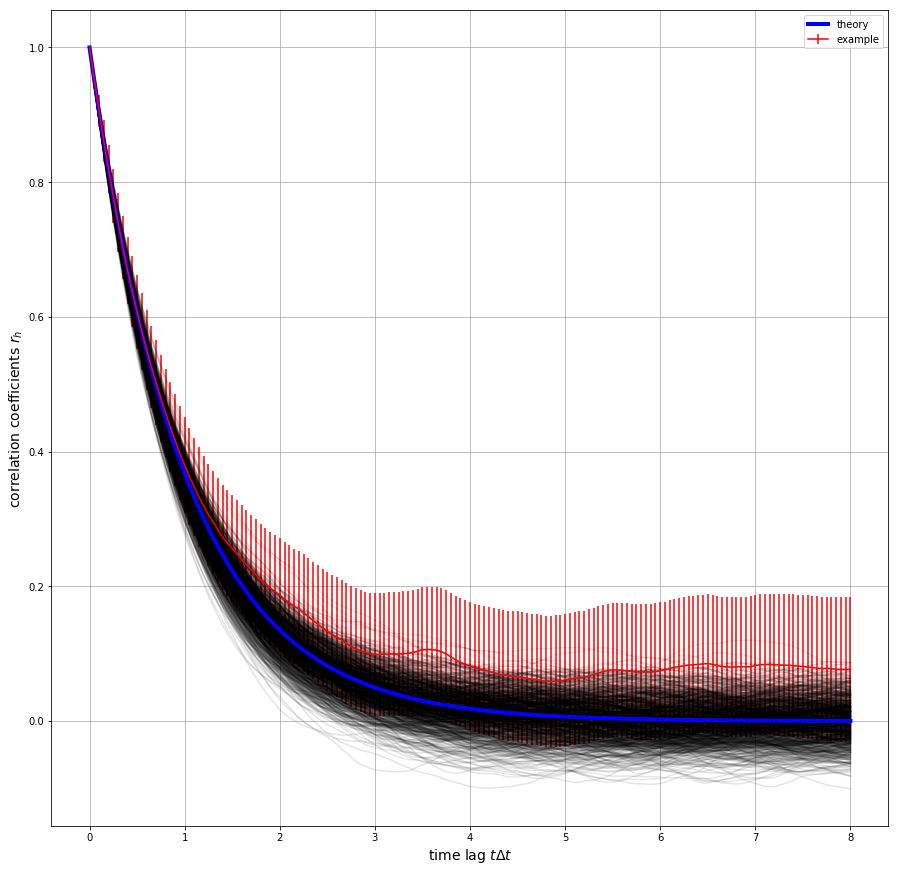

```python
# plot the correlations of individual tracks vs theory

tL = dT*np.arange(0,nLags+1)

fig,ax = plt.subplots(figsize=(15, 15))
ax.set_xlabel('time lag $t\Delta t$', fontsize=14)
ax.set_ylabel('correlation coefficients $r_h$', fontsize=14)
ax.grid()

# plot data
for iT in range(0,nT):

    ax.plot(tL,TrackList[iT].corr_V,'-',alpha=0.1,color='black')

ax.plot(tL,np.exp(-tL),label='theory',linewidth=4,color='blue')

# plot one example with errorbars
iT = np.random.randint(0, nT)
ax.errorbar(tL,TrackList[iT].corr_V,yerr=2.*TrackList[iT].u_corr_V,label='example',color='red')

plt.legend()
plt.show()
```

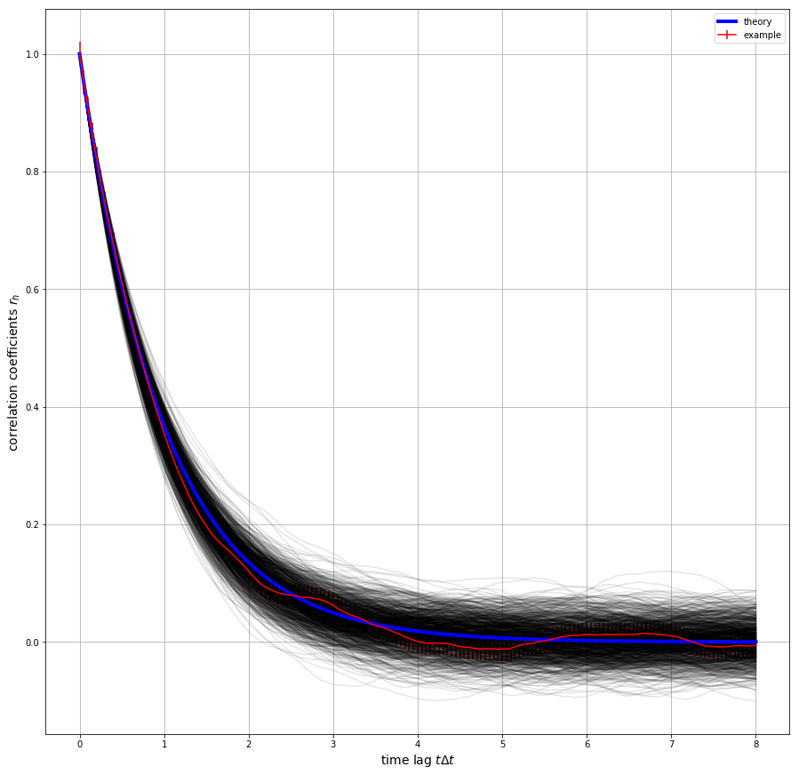

```python
# plot the correlations of with naiv error bar

tL = dT*np.arange(0,nLags+1)

fig,ax = plt.subplots(figsize=(15, 15))
ax.set_xlabel('time lag $t\Delta t$', fontsize=14)
ax.set_ylabel('correlation coefficients $r_h$', fontsize=14)
ax.grid()

# plot data
for iT in range(0,nT):

    ax.plot(tL,TrackList[iT].corr_V,'-',alpha=0.1,color='black')

ax.plot(tL,np.exp(-tL),label='theory',linewidth=4,color='blue')

# plot one example with errorbars
iT = np.random.randint(0, nT)
ax.errorbar(tL,TrackList[iT].corr_V,yerr=2./np.sqrt(nP)*np.ones_like(TrackList[0].u_corr_V),label='example',color='red')

plt.legend()
plt.show()
```

```python
# test the size of the error bar
xSig = 2.;

# couter for correct/wrong
indC = 0;
indW = 0;

# time lages
tL = dT*np.arange(0,nLags+1)

for iT in range(0,nT):

    # get the difference of true value and the estimate
    dif = np.abs( TrackList[iT].corr_V - np.exp(-tL) );

    if np.max( dif - xSig*TrackList[iT].u_corr_V ) > 0.:

        indW = indW + 1

    else:

        indC = indC + 1

print(indC/nT)
print(indW/nT)
```

```
0.949
0.051
```

## questions that occurred on the way issue

- Does the error scale with the temporal resolution? This cannot be correct as increasing the number of points.

  > no: we devide, notably, by N.
- What is the influence of subtracting the mean before calculating the correlation function?

  > This will introduce a bias for short, persistent tracks. What we want to see is also a measure for the persistence. For a short track which is persistent, one should not substract the mean drift as the result would give the dynamics of velocity fluctuations around the mean. This is not the measure which we are interested in. This is, thus, not a good idea.
- The results are not very sensitive to the question whether we use $|r_h|$ or $|r_h|^2$ for the calculation of the error bar.

### open issues

- How to average the x/y-components and when to normalize? This is particularly critical in the presence of positioning noise. Moreover, we have to think how to smooth the tracks.

### not functional

-> build in statistical model

```python
# comparison to the algorithms from StatsModels

mX,uX = sm.pacf(TrackList[0].vX,nlags=nLags,alpha=0.05)
mY,uY = sm.pacf(TrackList[0].vY,nlags=nLags,alpha=0.05)

tL = dT*np.arange(0,nLags+1)

fig,ax = plt.subplots(figsize=(15, 15))
ax.set_xlabel('time lag $t\Delta t$', fontsize=14)
ax.set_ylabel('correlation coefficients $r_h$', fontsize=14)
ax.grid()

ax.plot(tL,np.exp(-tL),label='theory',linewidth=4,color='blue')

ax.errorbar(tL,mX+mY,yerr=(uC[:,1]-uC[:,0])/2.,label='example',color='red')

# plot one example with errorbars
#iT = np.random.randint(0, nT)
#ax.errorbar(tL,TrackList[iT].corr_V,yerr=2./np.sqrt(nP)*np.ones_like(TrackList[0].u_corr_V),label='example',color='red')

plt.legend()
plt.show()
```

[output not shown]